# Independent Learning (IL):

*These objectives show your ability to seek out new information and adapt to new tools to solve data analysis problems.*

## [IL-1] Adding new skills:

- I can find and adopt new packages to accomplish tasks.
- I can adapt to different syntax styles (tidy, base, formula style, data.table).

### Level: 1

### Justification:

i utilized ggrepel to annotate

https://hersheyk.github.io/portfolio/posts/2025-05-01-Visualizations/visualizations.html#lab-2

## [IL-2] Online resources:

- I can use online resources (e.g., Google, ChatGPT, StackOverflow, YouTube) to solve problems, debug, or find new tools.
- I can use tutorials, etc. to enhance my understanding of new concepts.
- I can find source code for similar projects to use as starting points for my own.

### Level: 3

### Justification:

In Lab 2, there are many instances where I cite sources such as stack exchange to show where I found code or learned about specific functions.

## IL Summary

[figure not shown]

# Reproducible Workflow (RW):

*These objectives show your ability to produce artifacts and deliverables that are organized, documented, version tracked, and responsibly designed.*

## [RW-1] File, code, and data management:

- I can use Git and GitHub to track my progress (creating repos, cloning, forking, pull requesting).
- I always use R Projects and the {here} package to organize my scripts, notebooks, data, and applications.
- I always use pull requests when collaborating with others.

### Level: 2

### Justification:

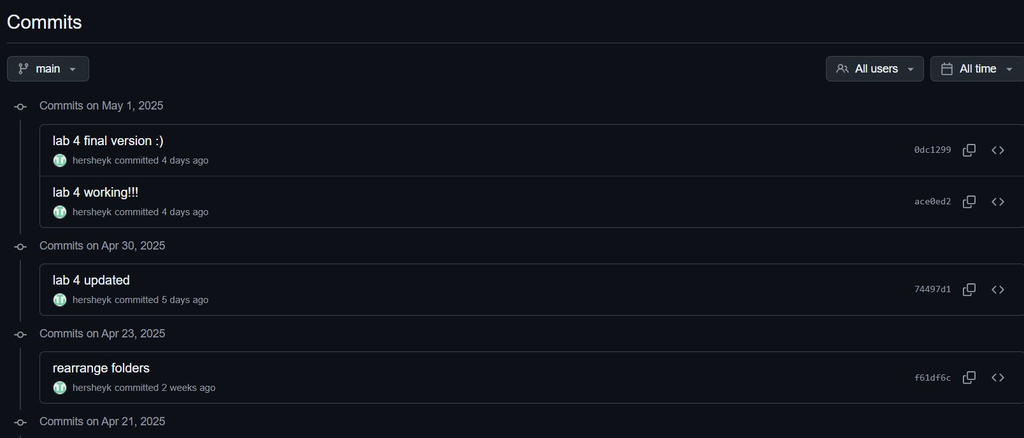

## [RW-2] Notebooks:

- I can use Quarto to produce a reproducible notebook and polished rendered documents
- I can use appropriate chunk options (echo, error, cache, etc.) to render my Quarto document quickly and cleanly.

### Level: 3

### Justification:

I have learned more about the various html options provided in quarto including YAML background colors, table of contents, code-folding and embedding resources. I also use code chunk options such as #| message: false to not output messages after specific code chunks(particularly useful in chunks where I call libraries or pull in data). I also label my code chunks, as seen below by {r calling data}

## [RW-3] Code style

- My code is clear, readable, well-organized, and well-commented.

### Level: 2

### Justification

I would say that I am very thorough about labeling code chunks(particularly because it makes it easy when I get an error as R informs me of the code chunk by name). I also am good about citing when I find code elsewhere, however I am not great at keeping my code clean and well-commented. Definitely something to work towards.

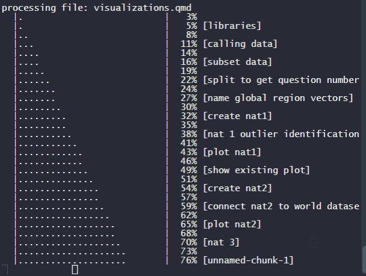

## RW Summary

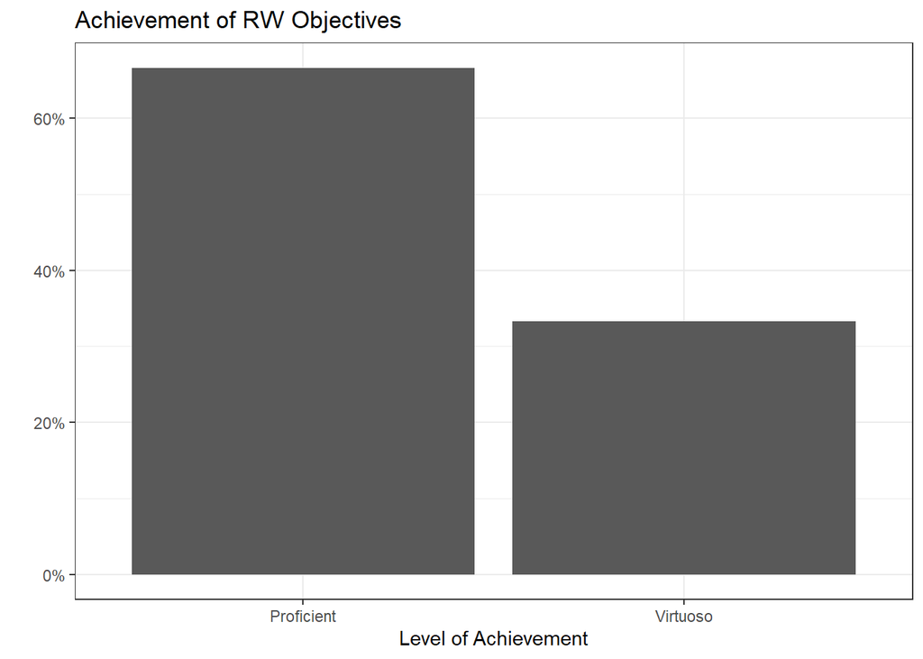

# Technical Communication (TC):

*These objectives show your ability to communicate the processes you have implemented in your code, as well as the data conclusions and results.*

## [TC-1] Project summaries:

- I can create clear and succinct summaries of a project.
- I accurately interpret statistical or modeling results.
- I consider the appropriate scope and impact of my project results.

### Level: 1

### Justification:

I don’t believe I have done this at all yet

## [TC-2] Documentation:

- I can create a user-friendly dashboard.
- I provide ample documentation for my custom functions.

### Level: 1

### Justification:

I have made a dashboard as seen on shinyapps. I have not made any custom functions to document.

https://ezd0m8-harshini-k.shinyapps.io/lab4/#belief-in-vaccine-safety-statistics

## TC Summary

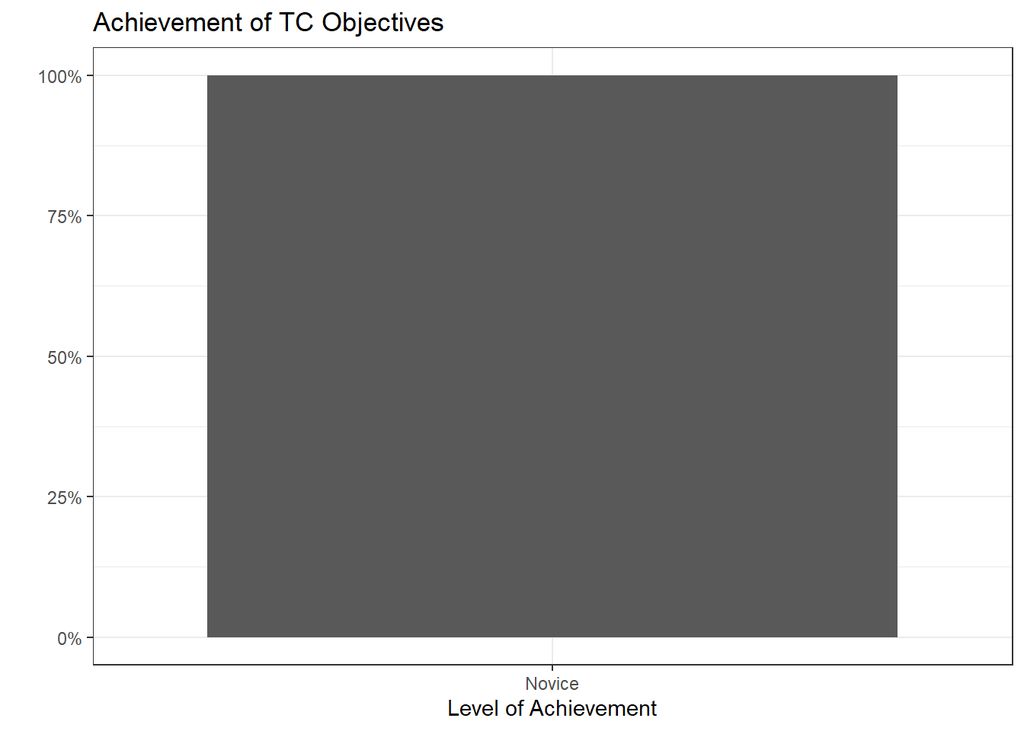

# Data Manipulation (DM):

*These objectives relate to the collection, cleaning, processing, and preparing of datasets for analysis.*

## [DM-1] Data Preparation

- I can read in datasets to R, including untidy ones.
- I can clean datasets to deal with missing data, typos, poor formatting, etc.

### Level: 2

### Justification:

I can read in data and I can pivot it and restructure the data as necessary to deal with formatting, as can be seen in Lab 2 where I restructure the however I do not believe I have had to deal with missing data or typos yet. I can read in different sheets of the same excel file.

## [DM-2] Data Wrangling

- I can cleverly use pivoting, separating, grouping, and joining to wrangle data.
- I can use mapping (`purrr`) to perform repeated tasks.

### Level: 2

### Justification:

While I have not used purrr I have extensively pivoted and joined data to create visualizations that answer specific questions or replicate specific outcomes

## [DM-3] Data Formats

- I can use API urls to access JSON data and convert it into a data frame
- I can scrape data from the web and convert it into a data frame

```r
## Fill in the line below with your self-assigned level for this objective.
my_level <- 1

portfolio_levels <- portfolio_levels %>%
  bind_rows(tibble(Objective = "DM-3",
                   Level = my_level))
```

### Level: 1

### Justification

I have not done this in R or in this class but I have doen it elsewhere? Not sure if that is relevant.

## DM Summary

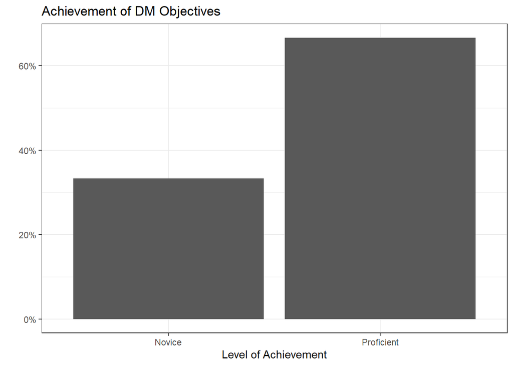

# Professional Visualization (PV):

## [PV-1] Clear & Accessible Visualizations

- I can make my plots more clear by removing the legend and adding annotations.
- I can edit the titles, subtitles, captions, axis labels, etc. to create a clearly labelled plot.
- I can choose colors (“scales”) and themes to make a visually pleasing and accessible plot.

### Level: 2

### Justification:

## [PV-2] Dynamic Visualizations

- I can use a package like {gganimate} to create self-contained gifs.
- I can use a package like {plotly}, {ggplotly}, {leaflet}, {ggirafe}, etc. to make interactive html widgets.

### Level: 2

### Justification:

I have not used gganimate to create a self-contained gif. I have, however used leaflet to make interactive widgets as seen on https://ezd0m8-harshini-k.shinyapps.io/lab4/#belief-in-vaccine-safety-statistics

## [PV-3] Interactive Visualizations

- I can use Shiny or webR to create visualizations that react to a user’s input.

### Level: 2

### Justification:

https://ezd0m8-harshini-k.shinyapps.io/lab4/#belief-in-vaccine-safety-statistics

## PV Summary

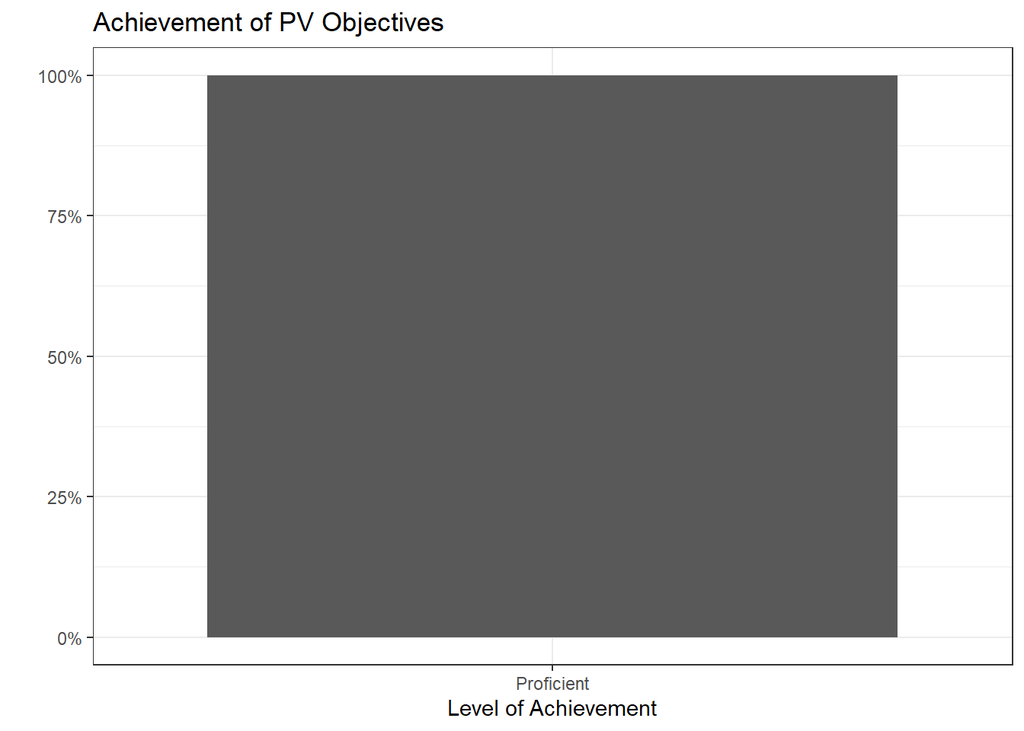

# Code Design, Algorithms, Iteration (CDAI):

*These objectives ask you to design code-based approaches to statistical computing problems, usually involving iteration to a stopping condition.*

## [CDAI-1] R Programming Language

- I understand non-standard evaluation (aka “tidy eval” or “unquoted objects”), and I can use tunneling in my functions.
- I understand functional programming, and I can use functions as objects in my code design.

### Level: 1

### Justification:

I have not done this yet

## [CDAI-2] Object Handling

- I have built in checks for possible input problems
- I can make reasonable choices in my code design about when to save intermediate objects.
- I can convert objects between types and structures as needed.

### Level: 1

### Justification:

I have not done this yet

## [CDAI-3] Speed and Efficiency

- I can recognize moments of possible slowdown in my code, and use built-in functions or parallelizing to speed them up.
- I always use and design vectorized functions whenever possible.

### Level: 1

### Justification:

I have not made any vectorized functions yet

## [CDAI-4] Supporting Functions

- I write helper / shortcut functions to streamline repeated tasks and make my code easier to read.
- I use intermediate functions to streamline repeated or looping processes.

### Level: 1

### Justification:

I have not made any shortcut functions yet

## [CDAI-5] Algorithmic Process

- I can invent and implement my own iterative algorithm.
- My loops are clean and efficient.
- I have built in checks for possible problems or extreme cases in the algorithm.

### Level: 1

### Justification:

I have not made an algorithms in this course yet.

## [CDAI-6] Generative Art

- I can apply a variety of generative art functions to make a visually pleasing piece.
- I can explain why particular changes to the code result in particular differences in the visualization.

### Level: 1

### Justification:

I have not made any generative art yet.

## CDAI Summary

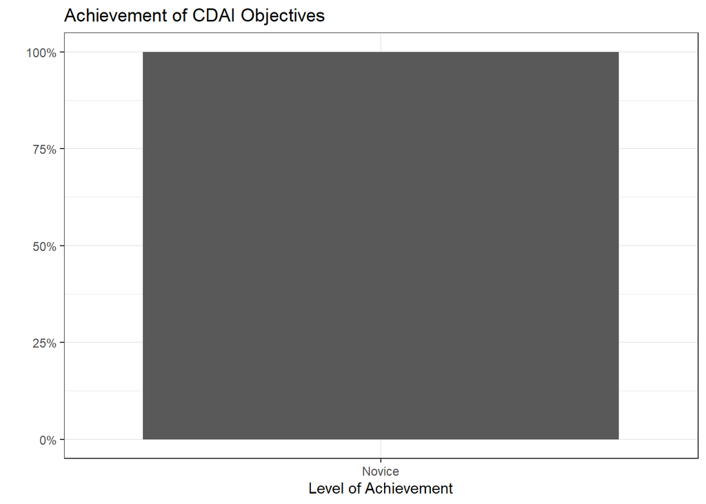

# Overall Summary

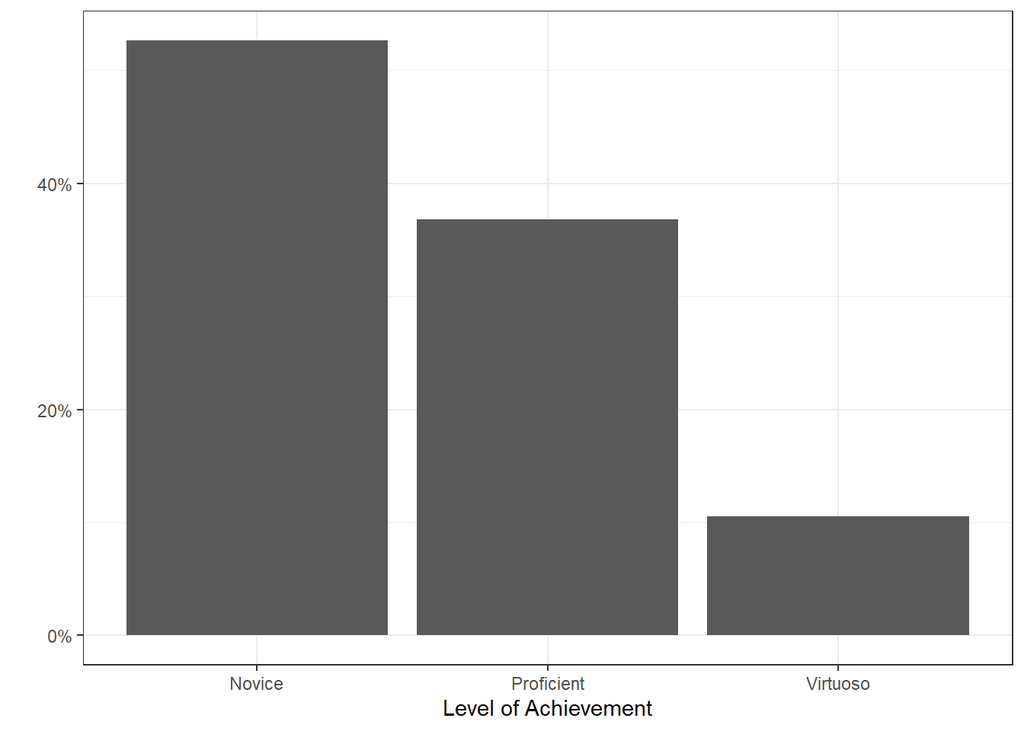